# New Plots 5-17

### Compare Montevideo and Durazno.

**Graph 27: Montevideo and Durazno BFD nuclear configurations (i.e., pitch accent + boundary tone) (not by Gender or age)**

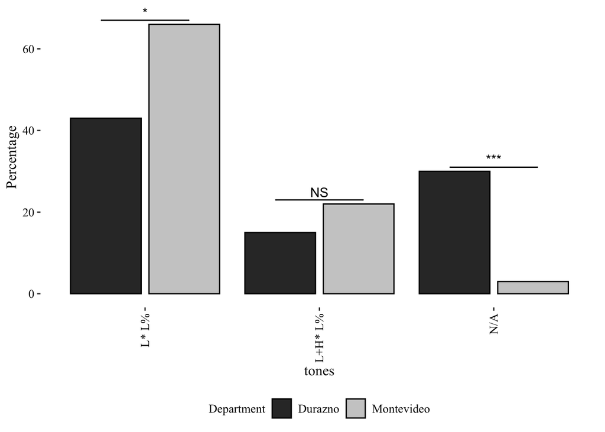

**Graph 28: Montevideo and Durazno non-focalized prenuclear pitch accents (combined count of prenuclear BFD and prenuclear non-focalized NFD PWs) Exclude L* and any pitch accent followed by an ip boundary tone L-, H-, !H-. like the one you already made but ensuring the combined count**

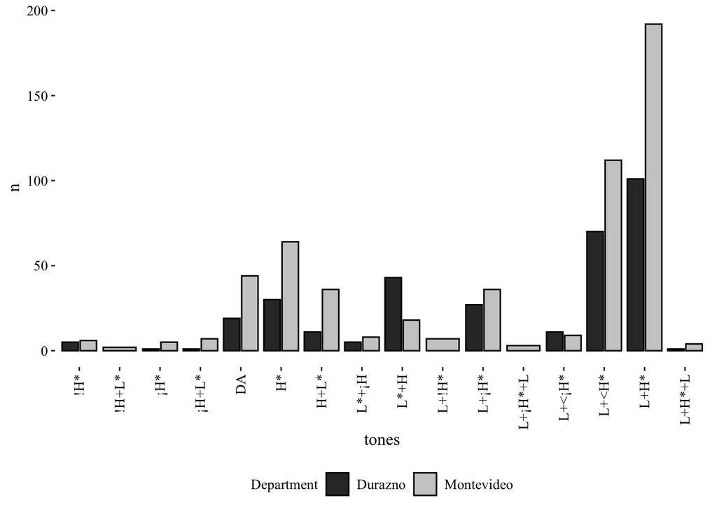

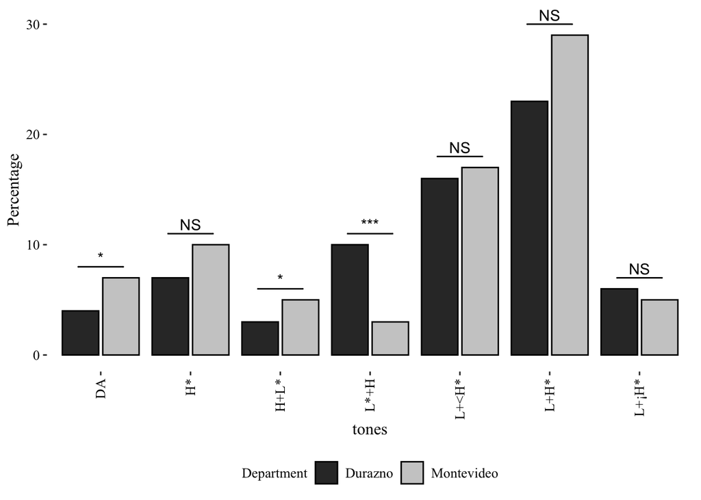

**Graph 29: Montevideo and Durazno focalized NFDs including pitch accents + boundary tones (like the graph you provided)**

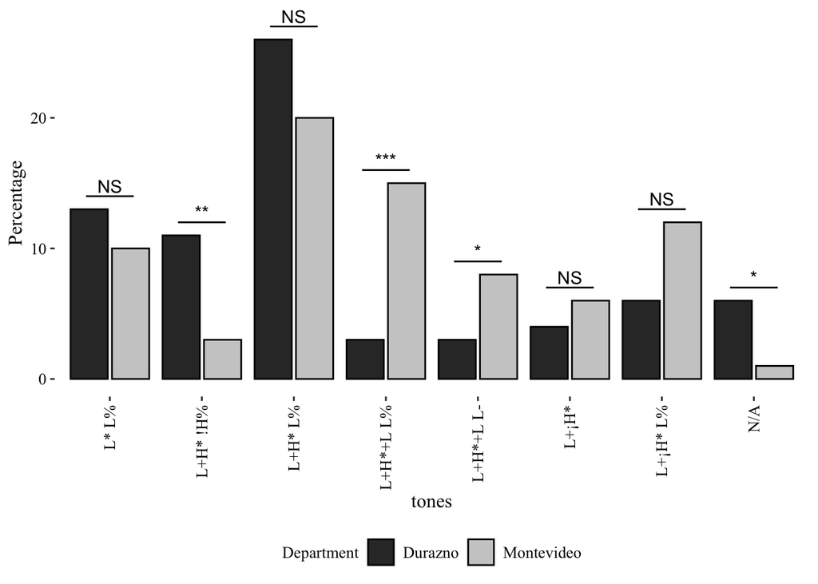

**NFD1 (Render each graph in such a way that I can present the three graphs side by side) At this point combining the two may no longer be worth it. I may just have to compare the two individual graphs, do you agree?**

> This is totally up to you. If you feel you have the time and space, we can make graphs like one below this message. This kind of plot gets to be pretty busy, given that there’s a lot going on on the x axis, so I don’t know if it’s worth it. If you want, though, we can trim to a minumum number of observations by one or both groups and run poisson regressions on all comparisons. This would take me ~1 hour. However, doing this for NFD1 means I can instantly do the same for all other sentences.

**Graph 30: NFD1 by city**

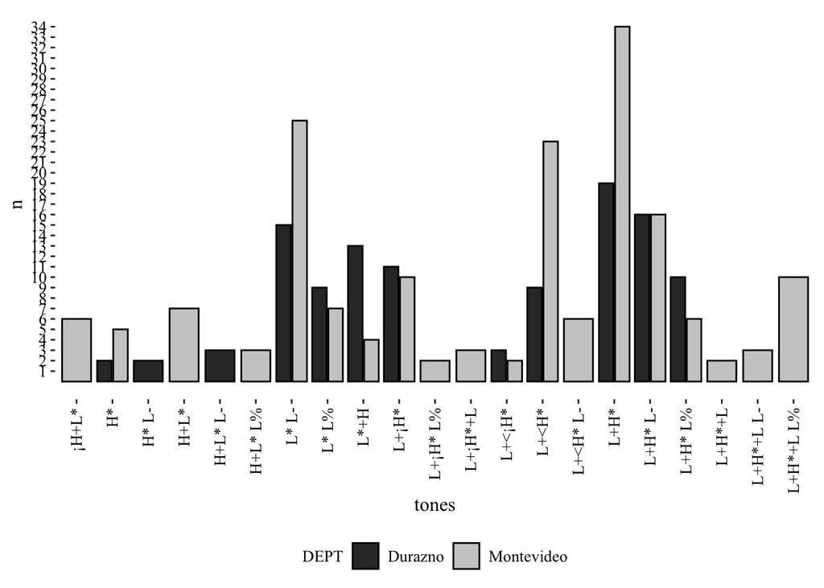

## Extra graphs, tables and models

**Extra Graph 1: Montevideo**

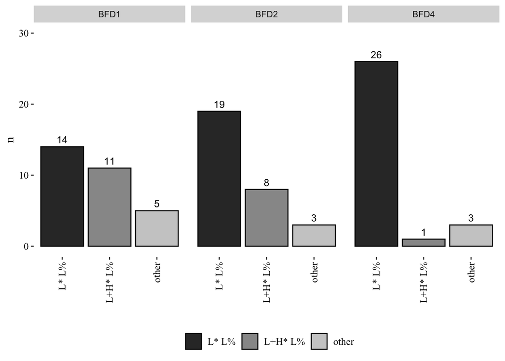

**Extra Graph 2: Durazno**

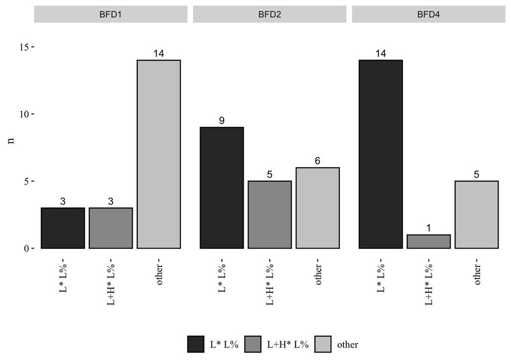

**Post-hoc models**

All models were run using the `glm` function in R. The models predicted the number of productions as a function of tones. **For the sake of time, I am leaving these p-values unrounded. As a general rule, significance is any p-value less than .05.

*Montevideo*

NFD1 36-59: The reference level is `L+H*+L`. Corresponding graph: 8c

Table A1: Poisson model summary predicting number of productions of a tone in Montevideo speakers ages 36-59 for NFD1

|  | Estimate | Std. Error | z value | p value |
| --- | --- | --- | --- | --- |
| (Intercept) | 1.95 | 0.38 | 5.15 | **< .005*** |
| tonesH+L* | -1.25 | 0.80 | -1.56 | 0.12 |
| tonesL* | -1.95 | 1.07 | -1.82 | 0.07 |
| tonesL+¡H* | -1.95 | 1.07 | -1.82 | 0.07 |

NFD3a female: The reference level is `H+L*`. Corresponding graph: 10e

Table A2: Poisson model summary predicting number of productions of a tone in Montevideo Females for NFD3a

|  | Estimate | Std. Error | z value | p value |
| --- | --- | --- | --- | --- |
| (Intercept) | 1.10 | 0.58 | 1.90 | 0.06 |
| tonesL* | 0.29 | 0.76 | 0.38 | 0.71 |
| tonesL+H* | 0.51 | 0.73 | 0.70 | 0.48 |
| tonesL+H*+L | 0.00 | 0.82 | 0.00 | 1 |

NFD4 female: The reference level is `L+¡H*`. Corresponding graph: 11b

Table A3: Poisson model summary predicting number of productions of a tone in Montevideo Females for NFD4

|  | Estimate | Std. Error | z value | p value |
| --- | --- | --- | --- | --- |
| (Intercept) | 2.30 | 0.32 | 7.28 | **< .005*** |
| tonesDA | -1.61 | 0.77 | -2.08 | *< .05** |
| tonesL+!H* | -2.30 | 1.05 | -2.20 | *< .05** |
| tonesL+H* | -2.30 | 1.05 | -2.20 | *< .05** |

NFD5 female: The reference level is `L+H*`. Corresponding graph: 12b

Table A4: Poisson model summary predicting number of productions of a tone in Montevideo Females for NFD5

|  | Estimate | Std. Error | z value | p value |
| --- | --- | --- | --- | --- |
| (Intercept) | 0.00 | 1.00 | 0.00 | 1 |
| tonesL+H* !H% | 0.69 | 1.22 | 0.57 | 0.57 |
| tonesL+H*+L | 2.48 | 1.04 | 2.39 | *< .05** |

*Durazno*

NFD6 female: The reference level is `L+H*`. Corresponding graph: 26b

Table A5: Poisson model summary predicting number of productions of a tone in Durazno Females for NFD6

|  | Estimate | Std. Error | z value | p value |
| --- | --- | --- | --- | --- |
| (Intercept) | 2.08 | 0.35 | 5.88 | **< .005*** |
| tonesL+¡H* | -2.08 | 1.06 | -1.96 | *< .05** |
| tonesL+¡H* H% | -2.08 | 1.06 | -1.96 | *< .05** |